# HW7

Yasasvi

2024-04-14

```r
library(ggplot2)
library(dplyr)
library(tidyr)
library(MASS)
data(iris)

str(iris)
```

```
## 'data.frame':    150 obs. of  5 variables:
##  $ Sepal.Length: num  5.1 4.9 4.7 4.6 5 5.4 4.6 5 4.4 4.9 ...
##  $ Sepal.Width : num  3.5 3 3.2 3.1 3.6 3.9 3.4 3.4 2.9 3.1 ...
##  $ Petal.Length: num  1.4 1.4 1.3 1.5 1.4 1.7 1.4 1.5 1.4 1.5 ...
##  $ Petal.Width : num  0.2 0.2 0.2 0.2 0.2 0.4 0.3 0.2 0.2 0.1 ...
##  $ Species     : Factor w/ 3 levels "setosa","versicolor",..: 1 1 1 1 1 1 1 1 1 1 ...
```

```r
model_simple <- lm(Petal.Length ~ Sepal.Length, data = iris)

summary(model_simple)
```

```
##
## Call:
## lm(formula = Petal.Length ~ Sepal.Length, data = iris)
##
## Residuals:
##      Min       1Q   Median       3Q      Max
## -2.47747 -0.59072 -0.00668  0.60484  2.49512
##
## Coefficients:
##              Estimate Std. Error t value Pr(>|t|)
## (Intercept)  -7.10144    0.50666  -14.02   <2e-16 ***
## Sepal.Length  1.85843    0.08586   21.65   <2e-16 ***
## ---
## Signif. codes:  0 '***' 0.001 '**' 0.01 '*' 0.05 '.' 0.1 ' ' 1
##
## Residual standard error: 0.8678 on 148 degrees of freedom
## Multiple R-squared:   0.76,  Adjusted R-squared:  0.7583
## F-statistic: 468.6 on 1 and 148 DF,  p-value: < 2.2e-16
```

Multiple Regression Analysis

Multiple regression analysis is a statistical method used to examine the relationship between a dependent variable and two or more independent variables. It extends simple linear regression, which deals with only one independent variable, to account for multiple predictors.

In multiple regression, the goal is to model the relationship between the dependent variable and the independent variables by fitting a linear equation to observed data.

Model Acceptance Model acceptance involves evaluating the performance of the multiple regression model on unseen data or a testing dataset

Residual Analysis Residual analysis is crucial for evaluating the assumptions of the multiple regression model and identifying any patterns or trends in the residuals

It will generate diagnostic plots, including a plot of residuals vs. fitted values, a QQ plot of residuals, and a scale-location plot. These plots can help you assess the assumptions of the multiple regression model.

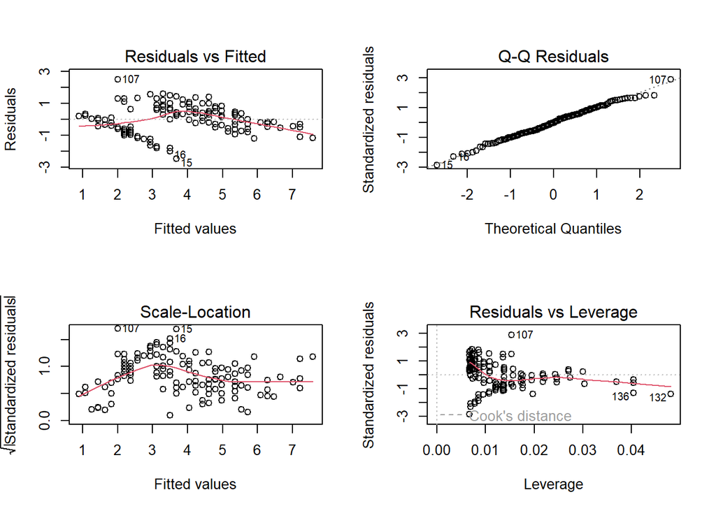

```r
# Residual analysis for the model
par(mfrow = c(2, 2)) # Set up a 2x2 grid for plots
plot(model_simple)
```

```r
# Model Accuracy for the model
rsquared_simple <- summary(model_simple)$r.squared
cat("R-squared for model:", rsquared_simple, "\n")
```

```
## R-squared for model: 0.7599546
```

```r
rmse_simple <- sqrt(mean((iris$Petal.Length - predict(model_simple))^2))
cat("RMSE for  model:", rmse_simple, "\n")
```

```
## RMSE for  model: 0.8620099
```

```r
# Check acceptance of the model
if (rsquared_simple > 0.5 & !any(model_simple$residuals > 2 | model_simple$residuals < -2)) {
  cat("model is accepted.\n")
} else {
  cat("model is not accepted.\n")
}
```

```
## model is not accepted.
```

```r
# Fit a multiple regression model with additional predictors
model_mult <- lm(Petal.Length ~ Sepal.Length + Sepal.Width + Petal.Width, data = iris)

# Summarize the model
summary(model_mult)
```

```
##
## Call:
## lm(formula = Petal.Length ~ Sepal.Length + Sepal.Width + Petal.Width,
##     data = iris)
##
## Residuals:
##      Min       1Q   Median       3Q      Max
## -0.99333 -0.17656 -0.01004  0.18558  1.06909
##
## Coefficients:
##              Estimate Std. Error t value Pr(>|t|)
## (Intercept)  -0.26271    0.29741  -0.883    0.379
## Sepal.Length  0.72914    0.05832  12.502   <2e-16 ***
## Sepal.Width  -0.64601    0.06850  -9.431   <2e-16 ***
## Petal.Width   1.44679    0.06761  21.399   <2e-16 ***
## ---
## Signif. codes:  0 '***' 0.001 '**' 0.01 '*' 0.05 '.' 0.1 ' ' 1
##
## Residual standard error: 0.319 on 146 degrees of freedom
## Multiple R-squared:  0.968,  Adjusted R-squared:  0.9674
## F-statistic:  1473 on 3 and 146 DF,  p-value: < 2.2e-16
```

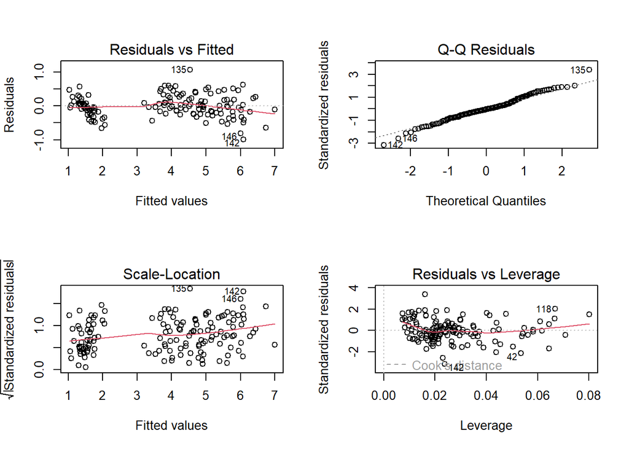

```r
# Residual analysis for the multiple regression model
par(mfrow = c(2, 2)) # Set up a 2x2 grid for plots
plot(model_mult)
```

Model Accuracy

Model accuracy can be assessed using various metrics, such as R-squared, adjusted R-squared, and root mean squared error (RMSE).

```r
# Model Accuracy for the multiple regression model
rsquared_mult <- summary(model_mult)$r.squared
cat("R-squared for multiple regression model:", rsquared_mult, "\n")
```

```
## R-squared for multiple regression model: 0.9680118
```

```r
rmse_mult <- sqrt(mean((iris$Petal.Length - predict(model_mult))^2))
cat("RMSE for multiple regression model:", rmse_mult, "\n")
```

```
## RMSE for multiple regression model: 0.3146739
```

```r
# Check acceptance of the multiple regression model
if (rsquared_mult > 0.7 & !any(model_mult$residuals > 2 | model_mult$residuals < -2)) {
  cat("Multiple regression model is accepted.\n")
} else {
  cat("Multiple regression model is not accepted.\n")
}
```

```
## Multiple regression model is accepted.
```

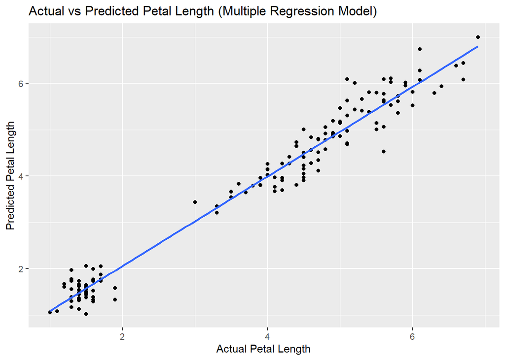

```r
# Visualize the predictions for the multiple regression model
iris_predicted_mult <- iris %>%
  mutate(Predicted_Petal_Length_mult = predict(model_mult))

ggplot(iris_predicted_mult, aes(x = Petal.Length, y = Predicted_Petal_Length_mult)) +
  geom_point() +
  geom_smooth(method = "lm", se = FALSE) +
  ggtitle("Actual vs Predicted Petal Length (Multiple Regression Model)") +
  xlab("Actual Petal Length") +
  ylab("Predicted Petal Length")
```

```r
# Compare models
cat("Comparison of model accuracies:\n")
```

```
## Comparison of model accuracies:
```

```r
cat("R-squared (Simple Model):", rsquared_simple, "\n")
```

```
## R-squared (Simple Model): 0.7599546
```

```r
cat("R-squared (Multiple Regression Model):", rsquared_mult, "\n")
```

```
## R-squared (Multiple Regression Model): 0.9680118
```

```r
cat("RMSE (Simple Model):", rmse_simple, "\n")
```

```
## RMSE (Simple Model): 0.8620099
```

```r
cat("RMSE (Multiple Regression Model):", rmse_mult, "\n")
```

```
## RMSE (Multiple Regression Model): 0.3146739
```